# R Notebook

We dispose of 829 air id’s information. View variables and distinct id’s.

```
[1] 829   5
```

```
          air_store_id air_genre_name                air_area_name
1 air_0f0cdeee6c9bf3d7 Italian/French Hyogo-ken Kobe-shi Kumoidori
2 air_7cc17a324ae5c7dc Italian/French Hyogo-ken Kobe-shi Kumoidori
3 air_fee8dcf4d619598e Italian/French Hyogo-ken Kobe-shi Kumoidori
4 air_a17f0778617c76e2 Italian/French Hyogo-ken Kobe-shi Kumoidori
5 air_83db5aff8f50478e Italian/French Tokyo-to Minato-ku Shibakoen
6 air_99c3eae84130c1cb Italian/French Tokyo-to Minato-ku Shibakoen
  latitude longitude
1 34.69512  135.1979
2 34.69512  135.1979
3 34.69512  135.1979
4 34.69512  135.1979
5 35.65807  139.7516
6 35.65807  139.7516
```

```
    n
1 829
```

### Genre type of restaurant (air stores)

Type of restaurant

| air_genre_name | n |
| --- | --- |
| Izakaya | 197 |
| Cafe/Sweets | 181 |
| Dining bar | 108 |
| Italian/French | 102 |
| Bar/Cocktail | 79 |
| Japanese food | 63 |
| Other | 27 |
| Yakiniku/Korean food | 23 |
| Western food | 16 |
| Okonomiyaki/Monja/Teppanyaki | 14 |
| Creative cuisine | 13 |
| Asian | 2 |
| International cuisine | 2 |
| Karaoke/Party | 2 |

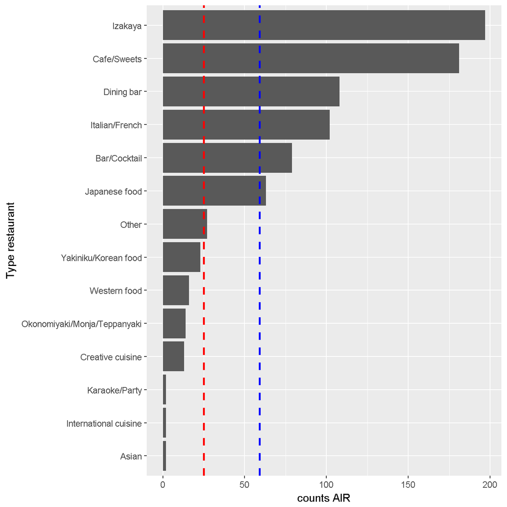

| mean_n | median_n |
| --- | --- |
| 59.21 | 25 |
| line blue | line red |

### Areas of air stores

We dispose of 103 distinct areas.

```
    n
1 103
```

#### Top 10 areas

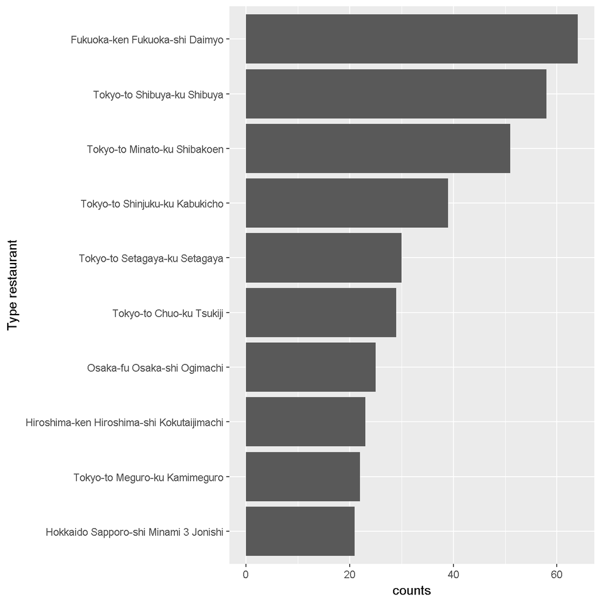

If we look top10, Tokyo is important. Search in areas the name **tokyo**. Tokyo areas represent 54% of data.

```
         n
1 0.535585
```

#### Filter some areas

Look names **tokyo,fukuoka,osaka** and compare genre of restaurant.

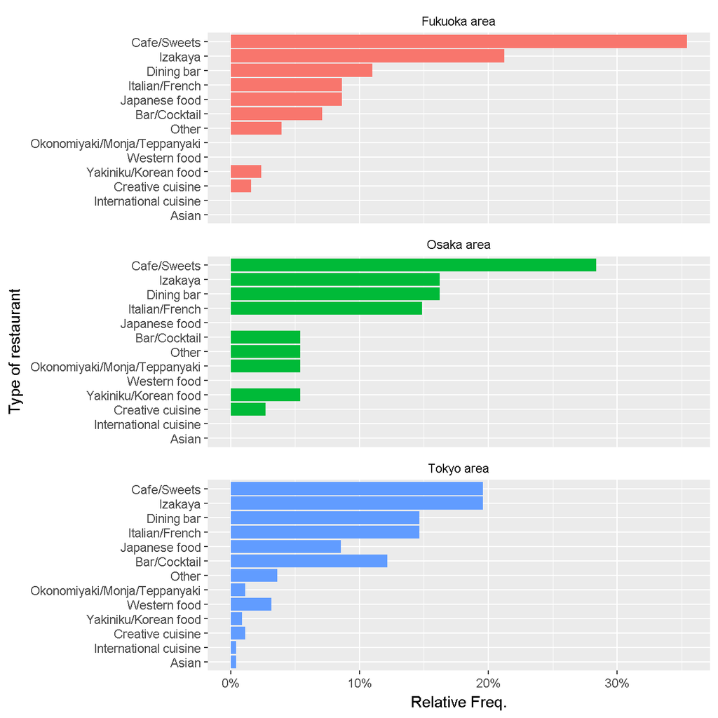

| area2 | air_genre_name | n | freq |
| --- | --- | --- | --- |
| Fukuoka area | Cafe/Sweets | 45 | 0.3543307 |
| Osaka area | Cafe/Sweets | 21 | 0.2837838 |
| Fukuoka area | Izakaya | 27 | 0.2125984 |
| Tokyo area | Cafe/Sweets | 87 | 0.1959459 |
| Tokyo area | Izakaya | 87 | 0.1959459 |
| Osaka area | Dining bar | 12 | 0.1621622 |
| Osaka area | Izakaya | 12 | 0.1621622 |
| Osaka area | Italian/French | 11 | 0.1486486 |
| Tokyo area | Dining bar | 65 | 0.1463964 |
| Tokyo area | Italian/French | 65 | 0.1463964 |
| Tokyo area | Bar/Cocktail | 54 | 0.1216216 |
| Fukuoka area | Dining bar | 14 | 0.1102362 |
| Fukuoka area | Italian/French | 11 | 0.0866142 |
| Fukuoka area | Japanese food | 11 | 0.0866142 |
| Tokyo area | Japanese food | 38 | 0.0855856 |
| Fukuoka area | Bar/Cocktail | 9 | 0.0708661 |
| Osaka area | Bar/Cocktail | 4 | 0.0540541 |
| Osaka area | Okonomiyaki/Monja/Teppanyaki | 4 | 0.0540541 |
| Osaka area | Other | 4 | 0.0540541 |
| Osaka area | Yakiniku/Korean food | 4 | 0.0540541 |
| Fukuoka area | Other | 5 | 0.0393701 |
| Tokyo area | Other | 16 | 0.0360360 |
| Tokyo area | Western food | 14 | 0.0315315 |
| Osaka area | Creative cuisine | 2 | 0.0270270 |
| Fukuoka area | Yakiniku/Korean food | 3 | 0.0236220 |
| Fukuoka area | Creative cuisine | 2 | 0.0157480 |
| Tokyo area | Creative cuisine | 5 | 0.0112613 |
| Tokyo area | Okonomiyaki/Monja/Teppanyaki | 5 | 0.0112613 |
| Tokyo area | Yakiniku/Korean food | 4 | 0.0090090 |
| Tokyo area | Asian | 2 | 0.0045045 |
| Tokyo area | International cuisine | 2 | 0.0045045 |

With this classification, we have this rows by area:

```
# A tibble: 3 x 2
         area2     n
         <chr> <int>
1 Fukuoka area   127
2   Osaka area    74
3   Tokyo area   444
```

#### Create 4 auxiliars groups from areas

| area2 | n |
| --- | --- |
| Fukuoka area | 127 |
| Osaka area | 74 |
| Others area | 184 |
| Tokyo area | 444 |

### Air visits data

Look visitors by month;

[output not shown]

Group data by month and auxiliar area and compare mean and median.

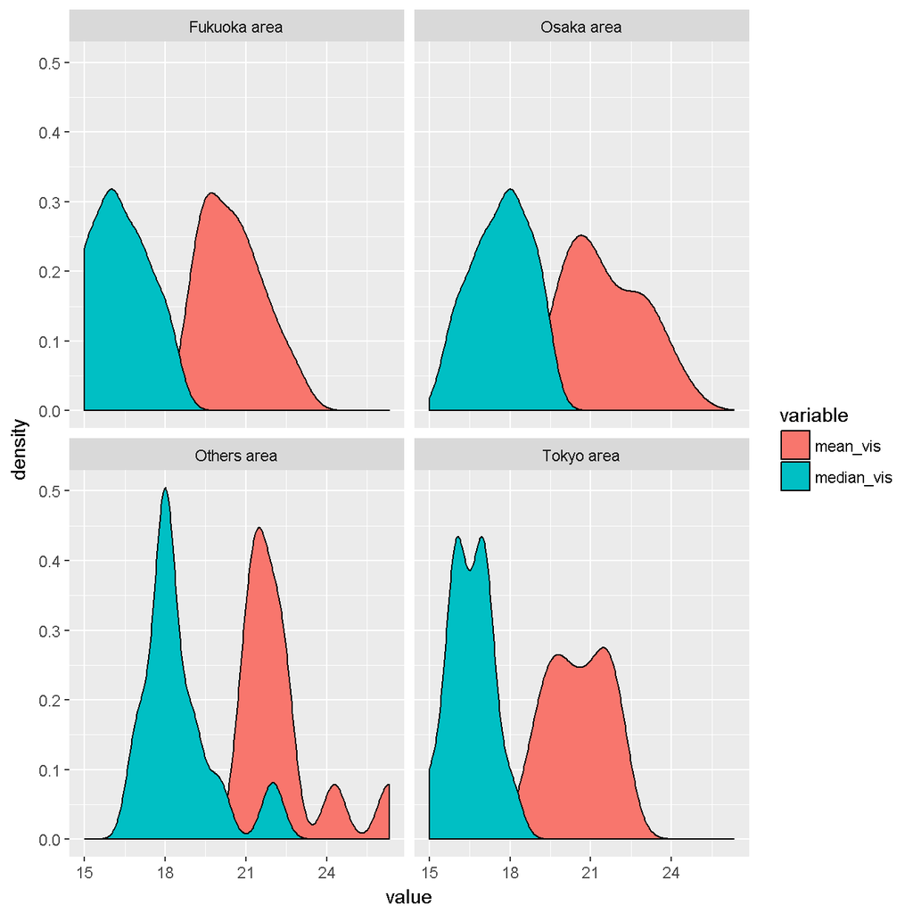

#### Median by year/month/auxiliar areas

Create auxiliar table for take anual medians by auxiliar areas. Compare this values by montly medians.

| air_year | area2 | median_y2 |
| --- | --- | --- |
| 2016 | Fukuoka area | 16 |
| 2016 | Osaka area | 18 |
| 2016 | Others area | 18 |
| 2016 | Tokyo area | 17 |
| 2017 | Fukuoka area | 15 |
| 2017 | Osaka area | 17 |
| 2017 | Others area | 19 |
| 2017 | Tokyo area | 17 |

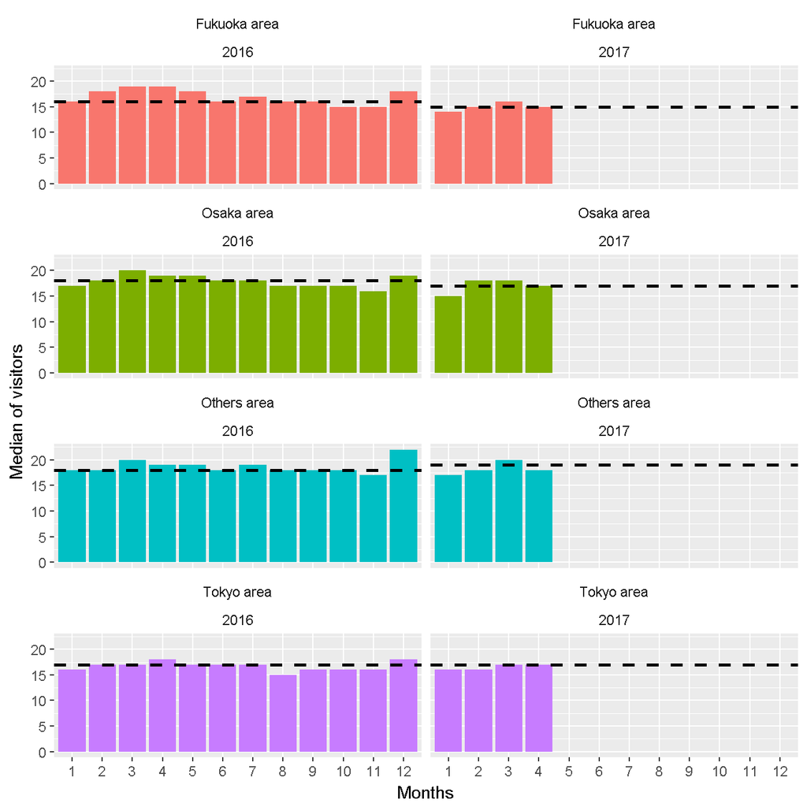

### Mean by aux. area/month/year with mark holiday_flag

Compare means if are holidays or not. Red color represents holiday_flag = 1 (yes).

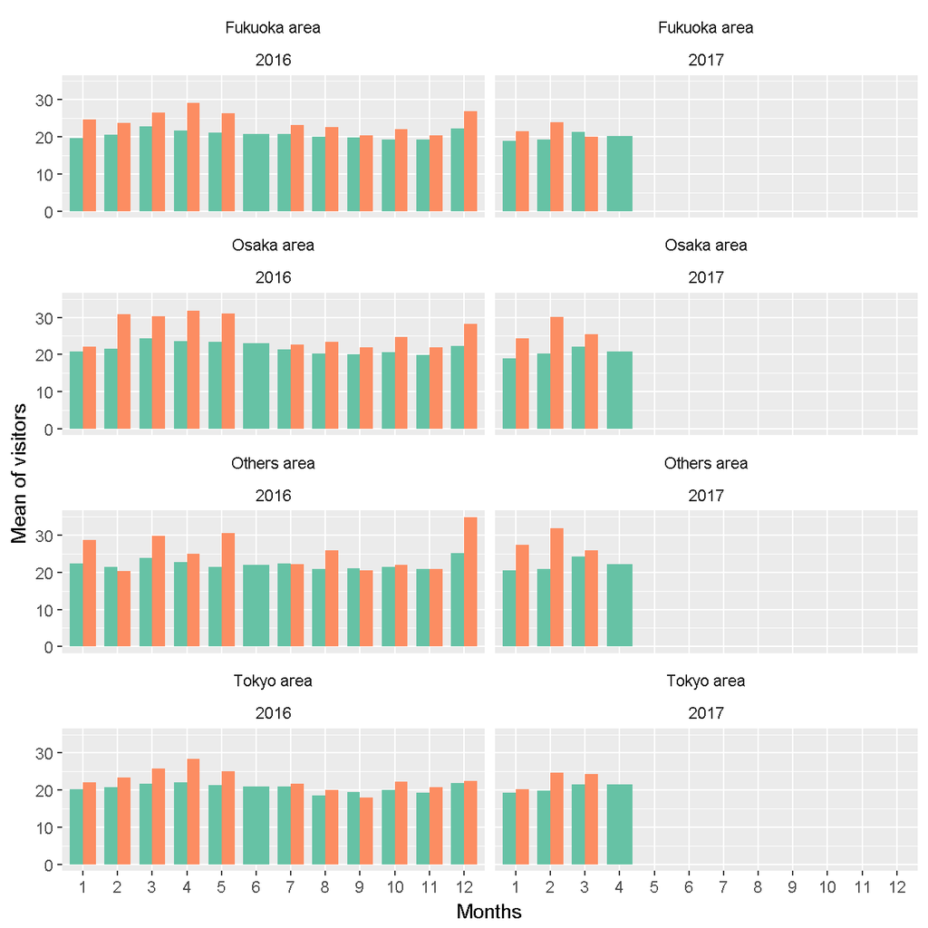

### Visitors in weekends

Densities with green color represents weekends. We can look more presence of visitors (in terms of median). Monday to Thursday we have great evidence than id’s restaurants have 15 visitors in general.

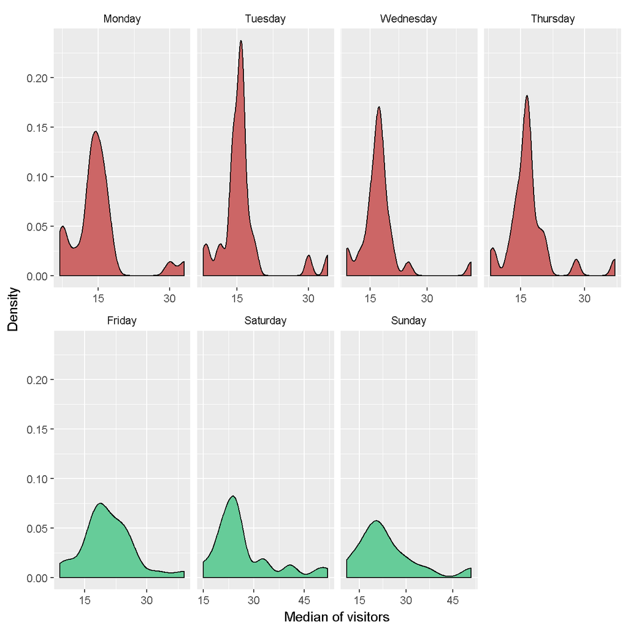

### Genres bether than mean (bests_genre)

Keep genres bether than mean (blue line in previous bar plot). We keep:

```
[1] "Izakaya"        "Cafe/Sweets"    "Dining bar"     "Italian/French"
[5] "Bar/Cocktail"   "Japanase food"
```

### Weekend by: bests_genre and auxiliar areas

First, search general median of visitors for weekends. The result is 20 (in previous densities we can look this pattern). Compare general median with auxiliar areas and weekend days (Friday,Saturday and Sunday). The most visual differences seem to be on Saturday.

**Note: (Dashed vertical line represent this general statistic)**

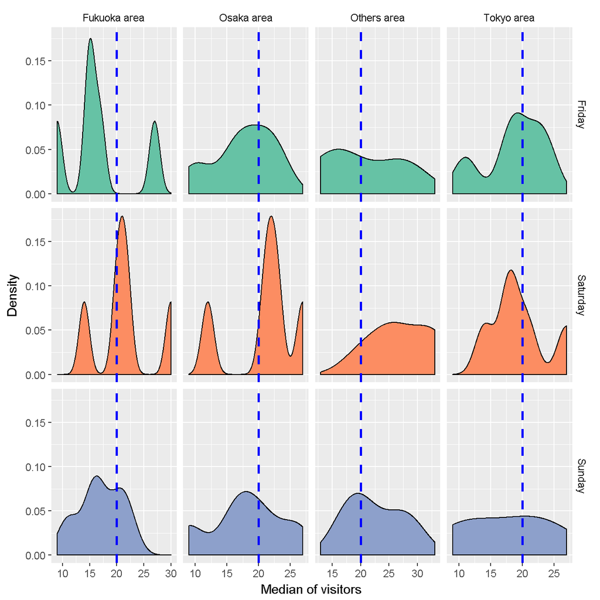

### Median of interaction Weekend, bests genre and auxiliar areas

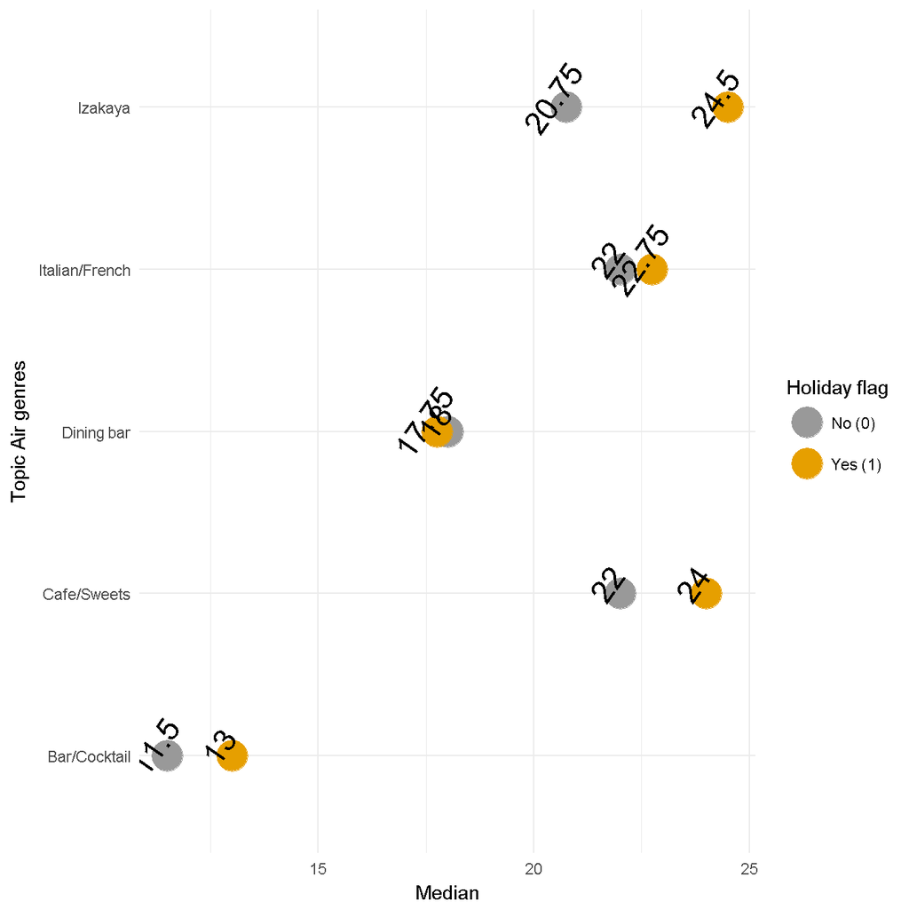

### Air reserve

We need to manipulate date type columns:

### Approach with reserve time

We only have 314 distinct id’s restaurant in air_reserve dataset:

```
    n
1 314
```

#### Reserve vs real visitors in auxiliar areas

We can look great differences with real visitors and reserves in air web.

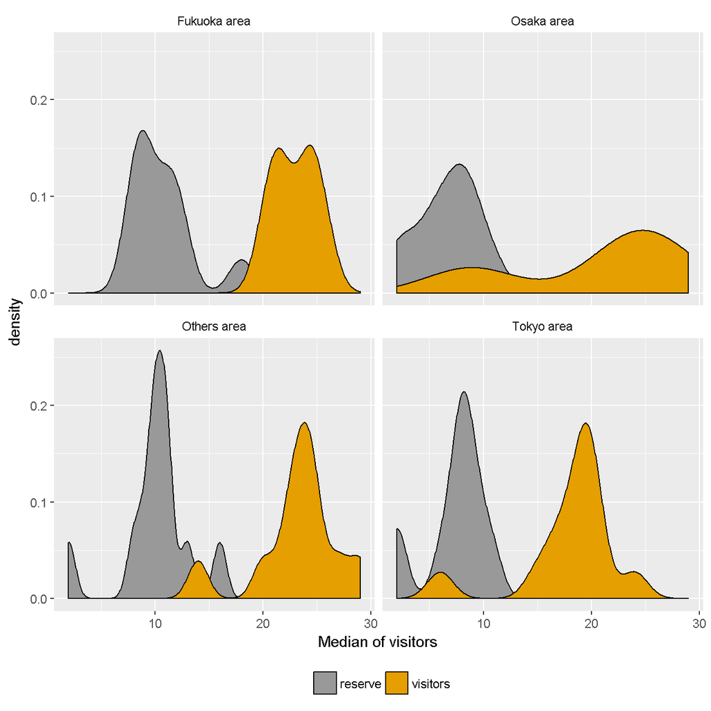